# Estimate so2 as a function of financial ratio (sector by sector)

# US Name

Estimate so2 as a function of financial ratio (sector by sector)

# Business needs

Estimate so2 as a function of financial ratio (Evalutate model for each sector separately)

## Description

### Objective

Test the coefficient sign and significant of the main variable

### Tables

1. Table 1: Baseline Estimate, so2 and financial ratio

**Cautious**

- Make sure no empty rows, otherwise it will be filtered out in the estimate

# Metadata

- Key: pkv56foxv40011s
- Parent key (for update parent):
- Epic: Models
- US: Sector by sector
- Task tag: #analytics,#baseline-table,#sector-estimate
- Notebook US Parent (i.e the one to update): https://github.com/thomaspernet/Financial_dependency_pollution/blob/master/02_data_analysis/01_model_estimation/00_estimate_fin_ratio/02_so2_fin_ratio_city_sector_by_sector.md
- Reports: https://htmlpreview.github.io/?https://github.com/thomaspernet/Financial_dependency_pollution/blob/master/02_data_analysis/01_model_estimation/00_estimate_fin_ratio/Reports/02_so2_fin_ratio_city_sector_by_sector.html
- Analytics reports:

# Input Cloud Storage [AWS/GCP]

## Table/file

- Name:
- asif_industry_financial_ratio_city
- Github:
  - https://github.com/thomaspernet/Financial_dependency_pollution/blob/master/01_data_preprocessing/02_transform_tables/03_asif_financial_ratio_city.md

# Load tables

Since we load the data as a Pandas DataFrame, we want to pass the `dtypes`. We load the schema from Glue to guess the types

|  | Name | Type | Comment |
| --- | --- | --- | --- |
| 0 | year | string | year from 2001 to 2007 |
| 1 | period | varchar(5) | False if year before 2005 included, True if year 2006 and 2007 |
| 2 | provinces | string |  |
| 3 | cityen | string |  |
| 4 | geocode4_corr | string |  |
| 5 | tcz | string | Two control zone policy city |
| 6 | spz | string | Special policy zone policy city |
| 7 | ind2 | string | 2 digits industry |
| 8 | short | string |  |
| 9 | polluted_di | varchar(5) | Sectors with values above Yearly 75th percentile of SO2 label as ABOVE else BELOW |
| 10 | polluted_mi | varchar(5) | Sectors with values above Yearly average of SO2 label as ABOVE else BELOW |
| 11 | polluted_mei | varchar(5) | Sectors with values above Yearly median of SO2 label as ABOVE else BELOW |
| 12 | tso2 | bigint | Total so2 city sector. Filtered values above 4863 (5% of the distribution) |
| 13 | so2_intensity | decimal(21,5) | SO2 divided by output |
| 14 | tso2_mandate_c | float | city reduction mandate in tonnes |
| 15 | in_10_000_tonnes | float | city reduction mandate in 10k tonnes |
| 16 | output | decimal(16,5) | Output |
| 17 | employment | decimal(16,5) | Employemnt |
| 18 | sales | decimal(16,5) | Sales |
| 19 | capital | decimal(16,5) | Capital |
| 20 | credit_constraint | float | Financial dependency. From paper https://www.sciencedirect.com/science/article/pii/S0147596715000311 |
| 21 | receivable_curasset_ci | double | 应收帐款 (c80) / cuasset |
| 22 | std_receivable_curasset_ci | double | standaridzed values (x - x mean) / std) |
| 23 | cash_over_curasset_ci | double | (其中：短期投资 (c79) - 应收帐款 (c80) - 存货 (c81) - 其中：产成品 (c82)) /current asset |
| 24 | std_cash_over_curasset_ci | double | standaridzed values (x - x mean) / std) |
| 25 | working_capital_ci | double | cuasset- 流动负债合计 (c95) |
| 26 | std_working_capital_ci | double | standaridzed values (x - x mean) / std) |
| 27 | working_capital_requirement_ci | double | 存货 (c81) + 应收帐款 (c80) - 应付帐款 (c96) |
| 28 | std_working_capital_requirement_ci | double | standaridzed values (x - x mean) / std) |
| 29 | current_ratio_ci | double | cuasset/流动负债合计 (c95) |
| 30 | std_current_ratio_ci | double | standaridzed values (x - x mean) / std) |
| 31 | quick_ratio_ci | double | (cuasset-存货 (c81) ) / 流动负债合计 (c95) |
| 32 | std_quick_ratio_ci | double | standaridzed values (x - x mean) / std) |
| 33 | cash_ratio_ci | double | (cuasset - 其中：短期投资 (c79) - 应收帐款 (c80) - 存货 (c81)/ 流动负债合计 (c95) |
| 34 | std_cash_ratio_ci | double | standaridzed values (x - x mean) / std) |
| 35 | liabilities_assets_ci | double | (流动负债合计 (c95) + 长期负债合计 (c97)) / toasset |
| 36 | std_liabilities_assets_ci | double | standaridzed values (x - x mean) / std) |
| 37 | return_on_asset_ci | double | sales - (主营业务成本 (c108) + 营业费用 (c113) + 管理费用 (c114) + 财产保险费 (c116) + 劳动、失业保险费 (c118)+ 财务费用 (c124) + 本年应付工资总额 (wage)) /toasset |
| 38 | std_return_on_asset_ci | double | standaridzed values (x - x mean) / std) |
| 39 | sales_assets_ci | double | 全年营业收入合计 (c64) /(\Delta toasset/2) |
| 40 | std_sales_assets_ci | double | standaridzed values (x - x mean) / std) |
| 41 | account_paybable_to_asset_ci | double | (\Delta 应付帐款 (c96))/ (\Delta (toasset)) |
| 42 | std_account_paybable_to_asset_ci | double | standaridzed values (x - x mean) / std) |
| 43 | asset_tangibility_ci | double | Total fixed assets - Intangible assets |
| 44 | std_asset_tangibility_ci | double | standaridzed values (x - x mean) / std) |
| 45 | rd_intensity_ci | double | rdfee/全年营业收入合计 (c64) |
| 46 | std_rd_intensity_ci | double | standaridzed values (x - x mean) / std) |
| 47 | inventory_to_sales_ci | double | 存货 (c81) / sales |
| 48 | std_inventory_to_sales_ci | double | standaridzed values (x - x mean) / std) |
| 49 | lower_location | string | Location city. one of Coastal, Central, Northwest, Northeast, Southwest |
| 50 | larger_location | string | Location city. one of Eastern, Central, Western |
| 51 | coastal | string | City is bordered by sea or not |
| 52 | fe_c_i | bigint | City industry fixed effect |
| 53 | fe_t_i | bigint | year industry fixed effect |
| 54 | fe_c_t | bigint | city industry fixed effect |

## Schema Latex table

To rename a variable, please use the following template:

```
{
    'old':'XX',
    'new':'XX_1'
    }
```

if you need to pass a latex format with `\`, you need to duplicate it for instance, `\text` becomes `\text:

```
{
    'old':'working\_capital\_i',
    'new':'\\text{working capital}_i'
    }
```

Then add it to the key `to_rename`

```
 Hlavac, Marek (2018). stargazer: Well-Formatted Regression and Summary Statistics Tables.
 R package version 5.2.2. https://CRAN.R-project.org/package=stargazer
```

# Expected signs

| index | Metrics | comments | variables | Roam_link | Exepected sign | Comment |
| --- | --- | --- | --- | --- | --- | --- |
| 1 | External finance dependence | From #[[Fan et al. 2015 - Credit constraints, quality, and export prices - Theory and evidence from China]] |  | #external-finance-dependence | Negative | An industry’s external finance dependence (ExtFini) is defined as the share of capital expenditure not financed with cash flows from operations. If external finance dependence is high, the industry is… |
| 2 | R&D intensity | RD / Sales | rdfee/sales | #rd-intensity | Negative | Share of RD expenditure over sales. larger values indicates larger use of sales to spend on RD. Say differently, lower borrowing done toward RD |
| 3 | Inventory to sales | Inventory / sales | 存货 (c81) / sales | #inventory-to-sales | Negative | Share of inventory over sales. Larger values indicates share of unsold or not consumed items. large values is a demonstration of tighter credit constraint |
| 4 | % receivable | receivable account / current asset | 应收帐款 (c80) / cuasset | #account-receivable #current-asset | Negative | Share of receivable over current asset. Larger value indicates longer time before collecting the money from the customers |
| 5 | Liabilities over asset | (Short-Tern Debt + Long-Term Debt)/total asset | 1- (流动负债合计 (c95) + 长期负债合计 (c97)) / toasset | #total-debt-to-total-assets | Negative | Share of liabilities over total asset. Larger value indicates assets that are financed by external creditors |
| 6 | working capital requirement | Inventory + Accounts receivable - Accounts payable | 存货 (c81) + 应收帐款 (c80) - 应付帐款 (c96) | #working-capital | Negative | Working Capital Requirement is the amount of money needed to finance the gap between disbursements (payments to suppliers) and receipts (payments from customers). Larger values indicate the amount of … |
| 7 | % cash | Current asset - cash / current asset | (cuasset- 其中：短期投资 (c79) - 应收帐款 (c80) - 存货 (c81) - 其中：产成品 (c82)) /current asset | #current-asset #cash | Positive | Share of cash asset over current asset. Larger values indicate more cash in hand. |
| 8 | cash ratio | (Cash + marketable securities)/current liabilities | 1-(cuasset - 其中：短期投资 (c79) - 应收帐款 (c80) - 存货 (c81) - 其中：产成品 (c82))/ 流动负债合计 (c95) | #cash-asset #cash-ratio | Positive | Cash divided by liabilities. A portion of short-term debt that can be financed by cash. A larger value indicates the company generates enough cash to cope with the short term debt |
| 9 | Working capital | Current asset - current liabilities | cuasset- 流动负债合计 (c95) | #working-capital-requirement | Positive | Difference between current asset and current liabilities. Larger value indicates that assets are enough to cope with the short term need |
| 10 | current ratio | Current asset /current liabilities | cuasset/流动负债合计 (c95) | #current-ratio | Ambiguous | Asset divided by liabilities. Values above 1 indicate there are more assets than liabilities. There are two effects on the liquidity constraint. Larger values imply the company has more liquidity, hen… |
| 11 | Quick ratio | (Current asset - Inventory)/current liabilities | (cuasset - 其中：短期投资 (c79) - 应收帐款 (c80) - 存货 (c81)) / 流动负债合计 (c95) | #quick-ratio | Ambiguous | The quick ratio is a measure of liquidity. The higher the more liquid the company is. To improve the ratio, the company should reduce the account receivable (reduce payment time) and increase the acco… |
| 12 | Return on Asset | Net income / Total assets | sales - (主营业务成本 (c108) + 营业费用 (c113) + 管理费用 (c114) + 财产保险费 (c116) + 劳动、失业保险费 (c118)+ 财务费用 (c124) + 本年应付工资总额 (wage)) /toasset | #return-on-asset | Ambiguous | Net income over total asset. Capacity of an asset to generate income. Larger value indicates that asset are used in an efficiente way to generate income |
| 13 | Asset Turnover Ratio | Total sales / ((delta total asset)/2) | 全年营业收入合计 (c64) /($\Delta$ toasset/2) | #asset-turnover-ratio | Ambiguous | Sales divided by the average changes in total asset. Larger value indicates better efficiency at using asset to generate revenue |
| 14 | Asset tangibility | Total fixed assets - Intangible assets | tofixed - 无形资产 (c92) | #asset-tangibility | Ambiguous | Difference between fixed sset and intangible asset. Larger value indicates more collateral, hence higher borrowing capacity |
| 15 | Account payable to total asset | (delta account payable)/ (delta total asset) | ($\Delta$ 应付帐款 (c96))/ ($\Delta$$ (toasset)) | #change-account-paybable-to-change-total-assets | Ambiguous (favour positive) | Variation of account payable over variation total asset. If the nominator larger than the denominator, it means the account payable grew larger than an asset, or more time is given to pay back the sup… |

## Tables

Estimate the following equations for each industry

**Table 1: Determinant of SO2 emission: so2 and financial ratio**

$$ \begin{aligned} \text{SO2}{cit} &= \alpha \text{Financial ratio}_{ci} + \text{X}_{cit} + \gamma{t} + \epsilon_{cit} \end{aligned} $$

**Table 2: Variation of SO2 emission: so2 and and financial ratio**

$$ \begin{aligned} \text{SO2}{cit} &= \alpha \text{Financial ratio}_{ci} \times \text{Period} + \text{X}_{cit} + \gamma{t} + \gamma{c} + \epsilon_{cit} \end{aligned} $$

$$ \begin{aligned} \text{SO2}{cit} &= \alpha \text{Financial ratio}_{ci} \times \text{Period} \times \text{policy mandate}_c + \text{X}_{cit} + \gamma{t} + \gamma{c} + \epsilon_{cit} \end{aligned} $$

| short | credit_constraint |
| --- | --- |
| Coking | 0.62 |
| Smelting ferrous Metals | 0.33 |
| Paper | 0.07 |
| Computers and Other Electronic Equipment" | 0.02 |
| Smelting Non-ferrous Metals | -0.10 |
| Raw Chemical Materials | -0.23 |
| Rubber | -0.26 |
| Special Purpose Machinery | -0.27 |
| Non-metallic Products | -0.29 |
| Foods | -0.32 |
| Education and Sport Activity" | -0.40 |
| Chemical Fibers | -0.41 |
| Electrical Machine | -0.44 |
| Medicines | -0.44 |
| Plastics | -0.47 |
| Processing foods | -0.47 |
| Textile | -0.48 |
| Artwork | -0.62 |
| Furniture | -0.65 |
| Beverages | -0.72 |
| Manufacture of Wood | -0.72 |
| Transport Equipment | -0.72 |
| Reproduction of Recording Media" | -0.80 |
| Metals | -0.93 |
| Fur | -1.11 |
| Footwear | -1.32 |
| Cultural measurement instruments | -1.34 |
| Tobacco | -1.54 |
| Machinery | -2.59 |

| tso2_mandate_c | q_tso2_mandate_c |
| --- | --- |
| 0.0000000000 | 1 |
| 0.0003347627 | 1 |
| 0.0012153696 | 1 |
| 0.0012770165 | 1 |
| 0.0022988087 | 1 |
| 0.0024014567 | 1 |
| 0.0025244483 | 1 |
| 0.0030816750 | 1 |
| 0.0033873045 | 1 |
| 0.0034798288 | 1 |
| 0.0035886099 | 1 |
| 0.0037484514 | 1 |
| 0.0037583740 | 1 |
| 0.0038599886 | 1 |
| 0.0039370023 | 1 |
| 0.0043606960 | 1 |
| 0.0044421633 | 1 |
| 0.0052068260 | 1 |
| 0.0055612120 | 1 |
| 0.0059646620 | 1 |
| 0.0061610746 | 1 |
| 0.0063342430 | 1 |
| 0.0063989250 | 1 |
| 0.0069539575 | 1 |
| 0.0069765270 | 1 |
| 0.0073211150 | 1 |
| 0.0076149530 | 1 |
| 0.0089008430 | 1 |
| 0.0090756010 | 1 |
| 0.0091227100 | 1 |
| ... | ... |
| 0.2496068 | 3 |
| 0.2533172 | 3 |
| 0.2631977 | 3 |
| 0.2632913 | 3 |
| 0.2683650 | 3 |
| 0.2780177 | 3 |
| 0.2935140 | 3 |
| 0.3008184 | 3 |
| 0.3136532 | 3 |
| 0.3392294 | 3 |
| 0.3488054 | 3 |
| 0.3547216 | 3 |
| 0.3564066 | 3 |
| 0.3813583 | 3 |
| 0.3901870 | 3 |
| 0.3962854 | 3 |
| 0.4147041 | 3 |
| 0.4438487 | 3 |
| 0.4454129 | 3 |
| 0.4489273 | 3 |
| 0.4499935 | 3 |
| 0.4828971 | 3 |
| 0.4850300 | 3 |
| 0.5035972 | 3 |
| 0.5628856 | 3 |
| 0.5976742 | 3 |
| 0.7043114 | 3 |
| 0.9376135 | 3 |
| 1.0000000 | 3 |
| 1.3279083 | 3 |

Test filter policy mandate

```
Rank 1 in term of credit constraint
```

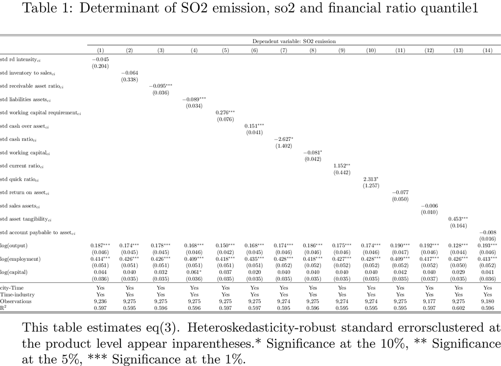

[output not shown]

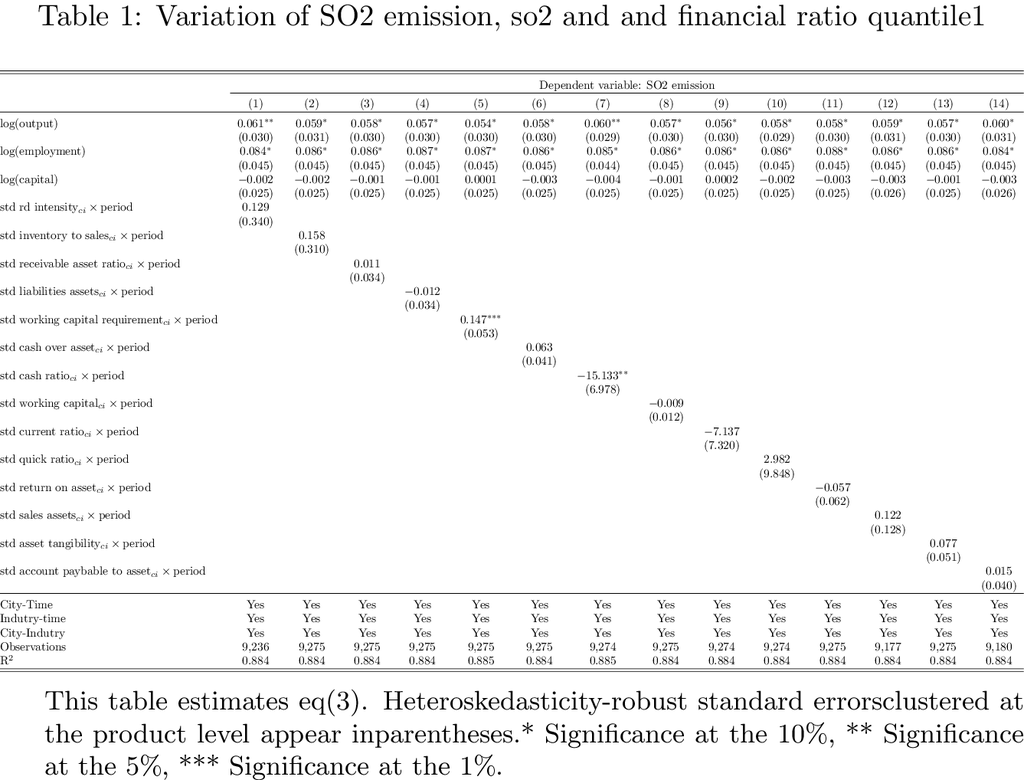

[output not shown]

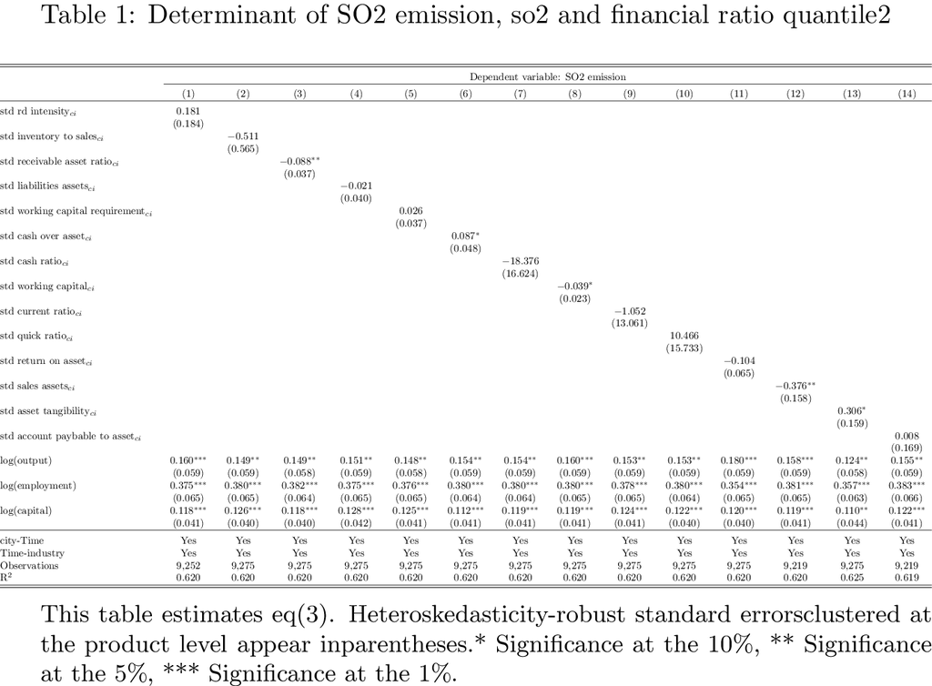

[output not shown]

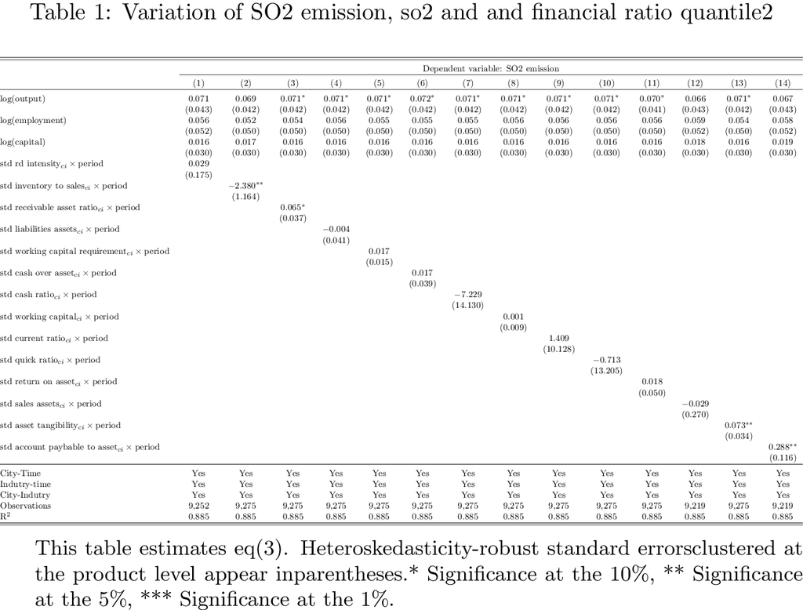

[output not shown]

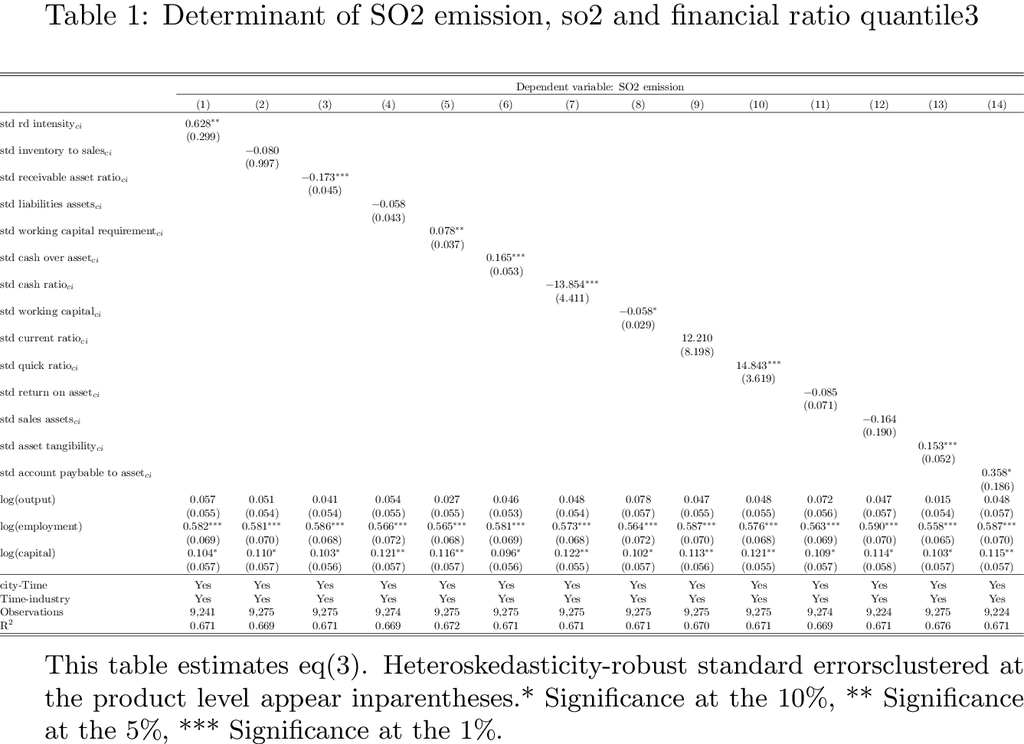

[output not shown]

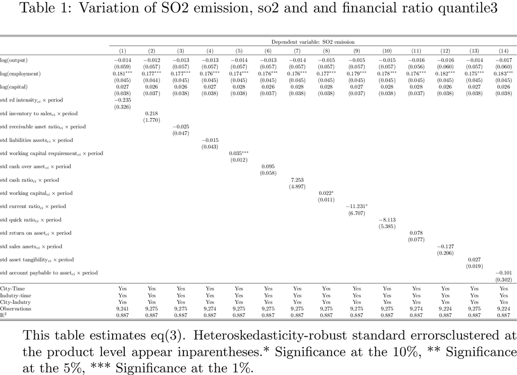

Remove table